# ETC-5513 Assignment 1

Yuhao Long

2023-03-24

## 0.1 Element 1: R code chunk for loading libraries

The main R packages in this report are *tidyverse*,*knitr* and *maps*.

## 0.2 Element 2: Overall introduction

On the cusp of global epidemic and economic slump, we have intuitively felt the burden of population aging on society. According to a startling demographic forecast from the [United Nations](https://www.un.org/en/global-issues/ageing), aging problem has evolved into a global concern: by 2050, one in six persons in the world (or 16%) will be over the age of 65 and a substantial ramp up from 703 million to 1.5 billion since 2019. Such change may restructure nowadays social welfare Systems and economic productivity.

Hence, Understanding the **attributes and rules of prospective aging population change** becomes more and more imperative.

## 0.3 Element 3: Research question

The research is targeted for G20 country members, which represent the worldwide largest economies with 80% GWP contributed. The topic we mainly focused on is : 1. what is the mean of median age in geographical distribution from 2012 to 2021 ?

2. what is the tendency of life expectancy among different median age countries? *Remark: Europe union is not considered in the data set, but add permanent member Spain in*

## 0.4 Element 4: Data set introduction

### 0.4.1 Part I

The [life_expectancy](https://ourworldindata.org/life-expectancy) is a data set from our world data website to measure entity’s life expectancy per year from 1950-2021. [median_age](https://ourworldindata.org/age-structure) is a data set from Our World Data website to measure entity’s median age per year starting from 1950 and end with prediction to 2100. The Population_research is a tidy data that combines necessary variables combined from median_age and life_expectancy，with the records of G20 members from 2012 to 2021 only.

Here is the following processing code for Population_research：

```r
#data reading
life_expectacy<-read.csv("Data/life-expectancy.csv",header = TRUE)
median_age<- read.csv("Data/median-age.csv", header = TRUE)

# create the list of G20 countries
G20<-c("Australia","United States","Canada","Saudi Arabia","India","China","Russia","Germany", "Mexico","Brazil","Argentina","Italy", "France", "United Kingdom","Turkey", "South Africa","Japan","South Korea","Indonesia","Spain")

# Data tidy and narrow for median age and life_expectancy
median_age_tidy<-median_age %>%
  filter(Year<= 2021 & Year>=2012,Entity %in% G20) %>%
  rename(median_age= "Median.age...Sex..all...Age..all...Variant..estimates") %>% mutate(Entity=(str_remove_all(Entity, " \\(UN\\)")), matcher=paste0(Entity,Code,Year))

life_expectacy_tidy<-life_expectacy  %>%
  filter(Year<= 2021 & Year>=2012,Entity %in% G20) %>%
  rename(life_expectacy = "Life.expectancy.at.birth..historical.") %>% mutate(matcher=paste0(Entity,Code,Year)) %>%
  select(life_expectacy:matcher)

# combine median age and life expectancy
Population_research <- left_join(median_age_tidy, life_expectacy_tidy, by="matcher") %>% select(Entity, Year, median_age, life_expectacy)

#save CSV
write.csv(Population_research,file="Data/Population_research.csv")
```

### 0.4.2 Part II

In Table 1, it shows the summary of Variable name (*“Entity”,“Year”,“life_expectancy” and “median_age”*) and the corresponding explanation that were collected for G20 countries from 2012 to 2021.

```r
#data frame creation
Kable_names<-data.frame(Variable_name=names(Population_research), Explaination=c("The country name in G20 members","the year of research conducted","an index that can segement entire population equally ","a statistical measure of the average time of a person longevity per country "))
```

```r
Kable_names %>% kable(booktabs= TRUE, caption = "The list of Variable names in Population_research")
```

Table 1: The list of Variable names in Population_research

| Variable_name | Explaination |
| --- | --- |
| Entity | The country name in G20 members |
| Year | the year of research conducted |
| median_age | an index that can segement entire population equally |
| life_expectacy | a statistical measure of the average time of a person longevity per country |

## 0.5 Element 5: Data set description

In Population_research data set, The number of observations are 200 and the number of variables are 4.

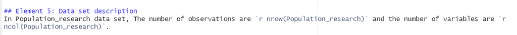

Figure 1: Screenshot

```r
knitr::include_graphics("Image/Screenshot.png")
```

Figure 1 depicts use incline code nrow to measure the total number of observations/rows and ncol to measure the total number of variables/columns.

To observe type of variables, use head function below:

```r
head(Population_research,2)
```

```
##      Entity Year median_age life_expectacy
## 1 Argentina 2012       29.3           76.5
## 2 Argentina 2013       29.5           76.5
```

In this data frame: The Entity is character variable, Year（integer), median_ age and life expectancy(double） are numeric variables.

## 0.6 Element 6: Results section

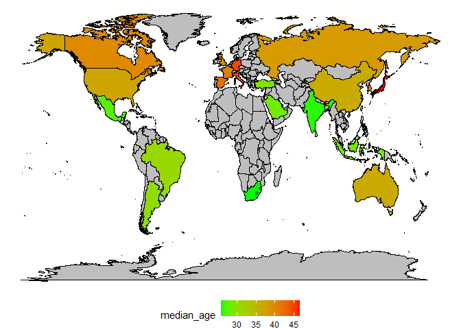

Figure 2: The median age distribution for G20 country

```r
#Set up map  boundary
World_map<- map_data("world") %>% arrange(region)

#Measure the median age mean by Entity and data tidy
Population_research_1 <- aggregate(median_age~ Entity, FUN  = mean,data= Population_research) %>%
  rename(region= Entity) %>%
  mutate(region= recode(region, "United Kingdom"="UK","United States"="USA"))

#File combination for map boundary and Population research
Graphic_1<- left_join(World_map, Population_research_1, by="region")

#Geom_map plot
ggplot(Graphic_1, aes( x= long, y= lat, map_id = region))+
geom_map(aes(fill = median_age), map=World_map , color="black") +
  scale_fill_gradient(low = "green", high = "red", na.value = "gray")  +
  theme_void() +
  theme( legend.position="bottom")
```

*1.Countries with high median populations（Color red pattern) are mainly concentrated in Western Europe and East Asia, whereas Latin America, South& South East Asia and Africa have relatively young populations(Color green pattern).* *2. Countries that are classified as high-income and well-developed in G20 are more vulnerable to the aging problem than less-developed countries.*

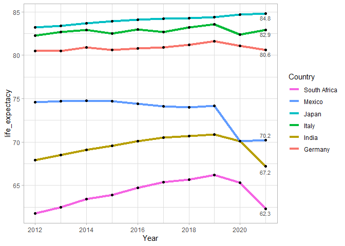

Figure 3: The life expectancy between 2012 and 2021

```r
# filter Top 3 and bottom 3 countries in median age
Top_Bottom_countries <-c("Japan","Germany","Italy","South Africa","India","Mexico")

# Geom_line plot the relationship between year and life_expectancy, filter by country
Population_research %>%
  filter(Entity %in% Top_Bottom_countries) %>%
  ggplot(aes(x= Year, y= life_expectacy, group= Entity, color= Entity)) +geom_line(size=1.5)+
  geom_point(color= "Black")+
  theme_light()+
  guides(color = guide_legend(title = "Country",reverse = TRUE))+
  annotate("text",x= 2021, y=c(84.3,82.4,80.1,70.8,66.5,61.8), label=c(84.8,82.9,80.6,70.2,67.2,62.3),size=3,color="gray31")
```

## 0.7 Appendix